# ST1131 Introduction to Statistics and Statistical Computing

## Tutorial 5

```python
# Verify the notebook is using venv-st1131
# You should see either \venv-st1131\Scripts\python.exe or /venv-st1131/bin/python
import sys
from pathlib import Path
print(Path(*Path(sys.executable).parts[-3:]))
```

```
venv-st1131/bin/python
```

```python
# Verify required packages
import numpy as np
import pandas as pd
import matplotlib.pyplot as plt
from math import comb #you can import the entire math too if you want using `import math`
from scipy import stats #you can be specific and import only binom and norm using 'from scipy.stats import binom, norm'

print("Everything works!")
```

```
Everything works!
```

Some important functions we will use are:

- `comb(n, x)` from `math` gives the binomial coefficient $C^n_x$.
- `stats.binom.pmf(x, n, p)` gives $P(X = x)$ and `stats.binom.cdf(x, n, p)` gives $P(X \le x)$ for $X \sim Bin(n, p)$.
- `stats.norm.cdf(x, loc, scale)` gives $P(X \le x)$, `stats.norm.ppf(q, loc, scale)` gives the $q$-th quantile, and `stats.norm.pdf(x, loc, scale)` gives the density, for $X \sim N(\mu, \sigma^2)$.

For `stats.norm`, `loc` is the mean $\mu$ and `scale` is the **standard deviation** $\sigma$, not the variance $\sigma^2$.

If you imported `binom` and `norm` instead of the entire `stats`, you do not need to write `stats.` at the front of the functions.

### Question 1

In the sport of athletics, individuals are randomly selected and tested for performance-enhancing drugs. The standard diagnostic test has a sensitivity of 0.993 and a specificity of 0.903. It is known that 5% of athletes really do take performance-enhancing drugs.

(a) Find the probability that a randomly selected athlete tests positive. Use Python to carry out the calculation.

```python
sens = 0.993
spec = 0.903
prev = 0.05

p_pos = sens * prev + (1 - spec) * (1 - prev)
print(f"P(+) = {p_pos:.4f}")
```

```
P(+) = 0.1418
```

Let $D$ be the event that the athlete takes performance-enhancing drugs. Using the Law of Total Probability,

$$ P(+) = P(+ \mid D)P(D) + P(+ \mid D^c)P(D^c) $$

$$ = (0.993)(0.05) + (1 - 0.903)(0.95) = 0.1418. $$

(b) If an athlete tests positive, a confirmatory test costing 10,000 dollars must be carried out. Let $X$ be a random variable that takes the value 10000 if a selected athlete tests positive, and 0 otherwise. Is $X$ discrete or continuous? Briefly explain your answer.

$X$ is **discrete**. It can only take two separate values, $0$ and $10000$, rather than any value in an interval.

(c) Write down the probability distribution of $X$. Hence, use Python to compute the mean and standard deviation of $X$ using

$$ \mu = \sum_x x\,p_x \qquad \text{and} \qquad \sigma^2 = \sum_x (x-\mu)^2\,p_x. $$

Interpret the mean in context.

```python
x = np.array([0, 10000])
p_x = np.array([1 - p_pos, p_pos])

mu_x = np.sum(x * p_x)
var_x = np.sum((x - mu_x)**2 * p_x)
sd_x = np.sqrt(var_x)

print(f"Mean = {mu_x:.2f}")
print(f"SD   = {sd_x:.2f}")
```

```
Mean = 1418.00
SD   = 3488.45
```

The probability distribution of $X$ is

| $x$ | 0 | 10000 |
| --- | --- | --- |
| $P(X = x)$ | 0.8582 | 0.1418 |

$$ \mu = 0(0.8582) + 10000(0.1418) = 1418 $$

$$ \sigma^2 = (0 - 1418)^2(0.8582) + (10000 - 1418)^2(0.1418) \approx 12{,}169{,}276, \qquad \sigma \approx 3488.45. $$

If a very large number of athletes were tested, the average confirmatory testing cost per athlete would be close to 1,418 dollars. No single athlete will ever cost exactly this amount, since each athlete costs either 0 or 10,000 dollars. The mean is a long-run average, not a value we expect to observe for one individual.

(d) The organising committee for an upcoming athletics meet selects 12 athletes at random for drug testing, and budgets 100,000 dollars for confirmatory testing. Assume the test results of different athletes are independent. Let $Y$ be the number of these 12 athletes who test positive.

State the distribution of $Y$, and find the probability that the committee exceeds its budget. Compute the probability using the binomial formula with `comb()`, then verify it using `stats.binom`.

```python
n_ath = 12

# Exceeding the budget means more than 10 positive results, so Y = 11 or Y = 12
p_11 = comb(n_ath, 11) * p_pos**11 * (1 - p_pos)**1
p_12 = comb(n_ath, 12) * p_pos**12 * (1 - p_pos)**0
print(f"Using the formula: {p_11 + p_12:.3e}")

print(f"Using stats.binom: {1 - stats.binom.cdf(10, n_ath, p_pos):.3e}")
```

```
Using the formula: 4.866e-09
Using stats.binom: 4.866e-09
```

Each of the 12 athletes either tests positive or not, each with the same probability 0.1418, independently. Hence

$$ Y \sim Bin(12,\ 0.1418). $$

Each positive result costs 10,000 dollars, so the budget is exceeded when $Y > 10$, that is, when $Y = 11$ or $Y = 12$:

$$ P(Y \ge 11) = C^{12}_{11}(0.1418)^{11}(0.8582) + C^{12}_{12}(0.1418)^{12} \approx 4.87 \times 10^{-9}. $$

The committee is extremely unlikely to exceed its budget.

Note that $P(Y \ge 10)$ would be incorrect: exactly 10 positive results costs exactly 100,000 dollars, which does **not** exceed the budget.

### Question 2

A snack kiosk on campus records the number of items, $M$, bought by each customer who stops at the kiosk. Based on past records, $M$ has the following probability distribution.

| $m$ | 0 | 1 | 2 | 3 | 4 |
| --- | --- | --- | --- | --- | --- |
| $P(M = m)$ | 0.15 | 0.35 | 0.25 | 0.15 | 0.10 |

(a) Store the values and probabilities as NumPy arrays and check in Python that this is a valid probability distribution. Draw a bar plot of the distribution and describe its shape.

```
All probabilities between 0 and 1: True
Sum of probabilities: 1.0
```

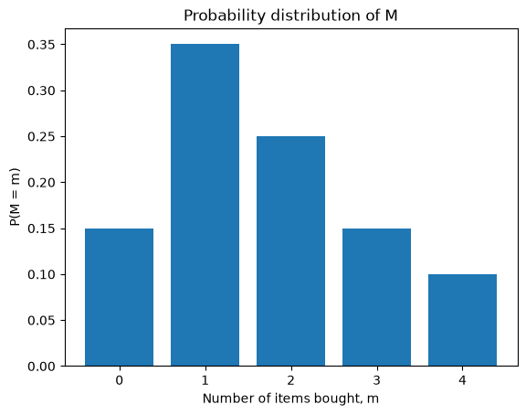

```python
m = np.array([0, 1, 2, 3, 4])
p_m = np.array([0.15, 0.35, 0.25, 0.15, 0.10])

print("All probabilities between 0 and 1:", np.all((p_m >= 0) & (p_m <= 1)))
print("Sum of probabilities:", p_m.sum())

plt.bar(m, p_m)
plt.xlabel("Number of items bought, m")
plt.ylabel("P(M = m)")
plt.title("Probability distribution of M")
plt.show()
```

Every probability lies between 0 and 1 and the probabilities sum to 1, so this is a valid probability distribution.

The distribution is unimodal with its peak at $m = 1$, and it is **right-skewed**: the probabilities trail off towards the larger values 3 and 4.

(b) Use Python to find the mean, variance and standard deviation of $M$.

```python
mu_m = np.sum(m * p_m)
var_m = np.sum((m - mu_m)**2 * p_m)
sd_m = np.sqrt(var_m)

print(f"Mean     = {mu_m:.4f}")
print(f"Variance = {var_m:.4f}")
print(f"SD       = {sd_m:.4f}")
```

```
Mean     = 1.7000
Variance = 1.4100
SD       = 1.1874
```

$$ \mu = 0(0.15) + 1(0.35) + 2(0.25) + 3(0.15) + 4(0.10) = 1.7 $$

$$ \sigma^2 = \sum_m (m - 1.7)^2 p_m = 1.41, \qquad \sigma = \sqrt{1.41} \approx 1.1874. $$

(c) The kiosk makes a profit of 1.50 dollars on each item sold, but gives every customer who stops by a free sample that costs 0.50 dollars. The profit from one customer is therefore

$$ Y = 1.5M - 0.5. $$

Use the properties of the mean and variance to find $E(Y)$ and the standard deviation of $Y$. Then verify your answers in Python by computing the values of $Y$ directly.

```python
# Using the properties
E_Y = 1.5 * mu_m - 0.5
sd_Y = 1.5 * sd_m
print(f"Using properties: E(Y) = {E_Y:.4f}, SD(Y) = {sd_Y:.4f}")

# Directly from the values of Y
y = 1.5 * m - 0.5
mu_y = np.sum(y * p_m)
sd_y = np.sqrt(np.sum((y - mu_y)**2 * p_m))
print(f"Directly:         E(Y) = {mu_y:.4f}, SD(Y) = {sd_y:.4f}")
```

```
Using properties: E(Y) = 2.0500, SD(Y) = 1.7812
Directly:         E(Y) = 2.0500, SD(Y) = 1.7812
```

Using $E(bM + a) = bE(M) + a$,

$$ E(Y) = 1.5(1.7) - 0.5 = 2.05. $$

Using $Var(bM + a) = b^2 Var(M)$,

$$ Var(Y) = 1.5^2(1.41) = 3.1725, \qquad SD(Y) = 1.5(1.1874) \approx 1.7812. $$

Both methods give the same answers.

The constant $-0.5$ shifts every value of $Y$ by the same amount, so it changes the mean but has **no effect** on the spread. A common mistake is to write $SD(Y) = 1.5\sigma - 0.5$.

### Question 3

A test for diabetes is based on glucose levels in the blood after fasting for a prescribed period. For healthy persons, fasting glucose levels are normally distributed with mean 5.31 mmol/L and standard deviation 0.58 mmol/L. For untreated diabetics, fasting glucose levels are normally distributed with mean 11.74 mmol/L and standard deviation 3.50 mmol/L.

To operate a simple screening test, we set a cut-off point $C$. If a patient's fasting glucose level is at least $C$, we say that they have diabetes. Otherwise, we say that they do not have diabetes.

(a) Find the sensitivity and specificity of the test if $C = 6.5$ is chosen as the cut-off point.

```python
mu_h, sd_h = 5.31, 0.58     # healthy
mu_d, sd_d = 11.74, 3.50    # diabetic

C = 6.5
sens_a = 1 - stats.norm.cdf(C, loc=mu_d, scale=sd_d)
spec_a = stats.norm.cdf(C, loc=mu_h, scale=sd_h)
print(f"C = {C}: sensitivity = {sens_a:.4f}, specificity = {spec_a:.4f}")
```

```
C = 6.5: sensitivity = 0.9328, specificity = 0.9799
```

Let $X_D \sim N(11.74,\ 3.50^2)$ and $X_H \sim N(5.31,\ 0.58^2)$ be the glucose levels of a diabetic and a healthy person respectively.

$$ \text{Sensitivity} = P(X_D \ge 6.5) \approx 0.9328 $$

$$ \text{Specificity} = P(X_H < 6.5) \approx 0.9799 $$

A common error is to pass the variance into `scale`, for example `stats.norm.cdf(6.5, 11.74, 3.50**2)`. The `scale` argument must be the standard deviation.

(b) Find the sensitivity and specificity of the test if $C = 5.7$ is used instead. Compare your answers with part (a).

```python
C = 5.7
sens_b = 1 - stats.norm.cdf(C, loc=mu_d, scale=sd_d)
spec_b = stats.norm.cdf(C, loc=mu_h, scale=sd_h)
print(f"C = {C}: sensitivity = {sens_b:.4f}, specificity = {spec_b:.4f}")
```

```
C = 5.7: sensitivity = 0.9578, specificity = 0.7493
```

$$ \text{Sensitivity} = P(X_D \ge 5.7) \approx 0.9578, \qquad \text{Specificity} = P(X_H < 5.7) \approx 0.7493. $$

Lowering the cut-off from 6.5 to 5.7 increases the sensitivity (more diabetics are correctly flagged) but decreases the specificity (more healthy people are wrongly flagged).

(c) What value of $C$ gives a sensitivity of 0.98? What is the specificity of the test at this cut-off? Comment on whether this is a sensible cut-off.

```python
C_98 = stats.norm.ppf(0.02, loc=mu_d, scale=sd_d)
spec_c = stats.norm.cdf(C_98, loc=mu_h, scale=sd_h)
print(f"C = {C_98:.4f}")
print(f"Specificity at this cut-off = {spec_c:.4f}")
```

```
C = 4.5519
Specificity at this cut-off = 0.0956
```

We need $P(X_D \ge C) = 0.98$, which means $P(X_D < C) = 0.02$. So $C$ is the 2nd percentile of the diabetic distribution:

$$ C = q_{0.02} \approx 4.552 \text{ mmol/L}. $$

At this cut-off, the specificity is only

$$ P(X_H < 4.552) \approx 0.0956. $$

This is not a sensible cut-off. About 90% of healthy people would be told they have diabetes. Since the diabetic distribution is very spread out, pushing the sensitivity this high forces $C$ below most healthy glucose levels.

(d) On the same axes, plot the probability density functions of the glucose levels for healthy persons and for diabetics, for glucose levels from 0 to 25 mmol/L. Add vertical lines at $C = 5.7$ and $C = 6.5$. Use the plot to explain why sensitivity and specificity cannot both be increased by moving $C$.

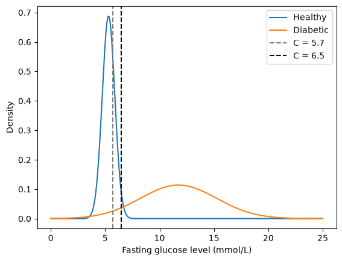

```python
g = np.linspace(0, 25, 500)

plt.plot(g, stats.norm.pdf(g, loc=mu_h, scale=sd_h), label="Healthy")
plt.plot(g, stats.norm.pdf(g, loc=mu_d, scale=sd_d), label="Diabetic")
plt.axvline(5.7, color="grey", linestyle="--", label="C = 5.7")
plt.axvline(6.5, color="black", linestyle="--", label="C = 6.5")
plt.xlabel("Fasting glucose level (mmol/L)")
plt.ylabel("Density")
plt.legend()
plt.show()
```

Sensitivity is the area under the **diabetic** curve to the right of $C$, and specificity is the area under the **healthy** curve to the left of $C$.

The two curves overlap. Moving $C$ to the left adds area to the right of $C$ under the diabetic curve (higher sensitivity) but removes area to the left of $C$ under the healthy curve (lower specificity). Moving $C$ to the right does the opposite. So any change in $C$ improves one measure at the expense of the other.

### Question 4

The yearly yield of butter fat from cows of a certain breed is normally distributed with mean 200 kg and standard deviation 20 kg. Let $Y_1$ and $Y_2$ be the yields of two unrelated cows from this breed, so that $Y_1$ and $Y_2$ are independent.

(a) Find $P(Y_1 < 190)$, $P(Y_2 > 245)$ and $P(190 < Y_1 < 245)$. For the first probability, convert 190 to a $Z$-score and use the standard normal distribution, then verify your answer using the original mean and standard deviation.

```python
mu_y, sd_y = 200, 20

z = (190 - mu_y) / sd_y
print(f"z = {z}")
print(f"P(Y1 < 190) using Z:  {stats.norm.cdf(z):.4f}")
print(f"P(Y1 < 190) using Y1: {stats.norm.cdf(190, loc=mu_y, scale=sd_y):.4f}")

print(f"P(Y2 > 245)       = {1 - stats.norm.cdf(245, loc=mu_y, scale=sd_y):.4f}")
p_c = stats.norm.cdf(245, loc=mu_y, scale=sd_y) - stats.norm.cdf(190, loc=mu_y, scale=sd_y)
print(f"P(190 < Y1 < 245) = {p_c:.4f}")
```

```
z = -0.5
P(Y1 < 190) using Z:  0.3085
P(Y1 < 190) using Y1: 0.3085
P(Y2 > 245)       = 0.0122
P(190 < Y1 < 245) = 0.6792
```

$$ Z = \frac{190 - 200}{20} = -0.5, \qquad P(Y_1 < 190) = P(Z < -0.5) \approx 0.3085. $$

Standardising does not change the probability, so both methods agree.

$$ P(Y_2 > 245) = 1 - P(Y_2 \le 245) \approx 0.0122 $$

$$ P(190 < Y_1 < 245) = P(Y_1 < 245) - P(Y_1 < 190) \approx 0.9878 - 0.3085 \approx 0.6792 $$

(b) A farmer wants to identify the top 10% of cows by yield. Find the yield above which a cow is in the top 10%.

```python
q90 = stats.norm.ppf(0.90, loc=mu_y, scale=sd_y)
print(f"90th percentile = {q90:.2f} kg")
```

```
90th percentile = 225.63 kg
```

We need the value $q_{0.90}$ such that $P(Y_1 \le q_{0.90}) = 0.90$:

$$ q_{0.90} \approx 225.63 \text{ kg}. $$

A cow with a yearly yield above about 225.63 kg is in the top 10%.

Note that we use `stats.norm.ppf(0.90, ...)`, not `stats.norm.ppf(0.10, ...)`. The top 10% lies to the right of the value, so 90% of the distribution lies to its left.

(c) Find $E(Y_2 - Y_1)$ and $Var(Y_2 - Y_1)$.

A student claims that since $Y_1$ and $Y_2$ have the same distribution,

$$ Var(Y_2 - Y_1) = Var(Y_2) - Var(Y_1) = 0. $$

Explain why the student is wrong.

$$ E(Y_2 - Y_1) = E(Y_2) - E(Y_1) = 200 - 200 = 0 $$

Since $Y_1$ and $Y_2$ are independent, taking $a_1 = -1$ and $a_2 = 1$,

$$ Var(Y_2 - Y_1) = (1)^2 Var(Y_2) + (-1)^2 Var(Y_1) = 400 + 400 = 800. $$

The student is wrong because the coefficient $-1$ is **squared**, so variances always add. Intuitively, the difference between two random yields is more uncertain than either yield on its own, not less. A variance of 0 would mean $Y_2 - Y_1$ is always exactly 0, which is clearly false for two different cows.

(d) Find the probability that the yield of the second cow exceeds the yield of the first cow by more than 30 kg.

```python
sd_diff = np.sqrt(800)
print(f"SD(Y2 - Y1)     = {sd_diff:.4f}")
print(f"P(Y2 - Y1 > 30) = {1 - stats.norm.cdf(30, loc=0, scale=sd_diff):.4f}")
```

```
SD(Y2 - Y1)     = 28.2843
P(Y2 - Y1 > 30) = 0.1444
```

A difference of independent normal variables is normal, so

$$ Y_2 - Y_1 \sim N(0,\ 800), \qquad SD(Y_2 - Y_1) = \sqrt{800} \approx 28.28. $$

Therefore,

$$ P(Y_2 - Y_1 > 30) \approx 0.1444. $$

### Question 5

A salesperson uses random digit dialling to call people and try to interest them in applying for a charge card for a large department store chain. From past experience, she is successful on 2% of her calls. In a typical working day, she makes 200 calls. Assume the outcomes of different calls are independent. Let $X$ be the number of calls on which she is successful.

(a) What type of distribution does $X$ have: normal, binomial, discrete but not binomial, or continuous but not normal? Briefly explain.

$X$ is **binomial**, $X \sim Bin(200,\ 0.02)$, because:

1. there are $n = 200$ calls, each with two outcomes (success or failure),
2. each call has the same probability of success $p = 0.02$, and
3. the calls are independent.

(b) Find the mean and standard deviation of $X$. Interpret the mean.

```python
n_calls, p_call = 200, 0.02
mu_calls = n_calls * p_call
sd_calls = np.sqrt(n_calls * p_call * (1 - p_call))
print(f"Mean = {mu_calls:.2f}, SD = {sd_calls:.4f}")
```

```
Mean = 4.00, SD = 1.9799
```

$$ E(X) = np = 200(0.02) = 4, \qquad SD(X) = \sqrt{np(1-p)} = \sqrt{3.92} \approx 1.98. $$

Over many working days, the salesperson averages about 4 successful calls per day.

(c) Find the probability that on a given day she has 0 successful calls, and the probability that she has at least 5 successful calls.

```python
print(f"P(X = 0)  = {stats.binom.pmf(0, n_calls, p_call):.4f}")
print(f"P(X >= 5) = {1 - stats.binom.cdf(4, n_calls, p_call):.4f}")
```

```
P(X = 0)  = 0.0176
P(X >= 5) = 0.3712
```

$$ P(X = 0) = C^{200}_{0}(0.02)^0(0.98)^{200} = 0.98^{200} \approx 0.0176 $$

$$ P(X \ge 5) = 1 - P(X \le 4) \approx 1 - 0.6288 = 0.3712 $$

Note that we subtract $P(X \le 4)$, not $P(X \le 5)$, since $X = 5$ must be included in "at least 5".

(d) Draw a bar plot of the probability distribution of $X$ for $x = 0, 1, \dots, 15$. Check whether the condition $np(1-p) \ge 5$ holds.

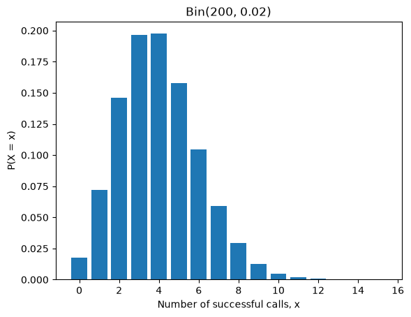

```
np(1-p) = 3.92
```

```python
xs = np.arange(0, 16)
plt.bar(xs, stats.binom.pmf(xs, n_calls, p_call))
plt.xlabel("Number of successful calls, x")
plt.ylabel("P(X = x)")
plt.title("Bin(200, 0.02)")
plt.show()

print(f"np(1-p) = {n_calls * p_call * (1 - p_call):.2f}")
```

The bar plot is **right-skewed**: it is cut off at 0 on the left and has a longer tail to the right.

$$ np(1-p) = 3.92 < 5, $$

so the condition for the normal approximation does not hold.

(e) Use Python to compare the exact value of $P(X \le 4)$ with the value given by the normal approximation, and comment.

```python
print(f"Exact P(X <= 4)         = {stats.binom.cdf(4, n_calls, p_call):.4f}")
print(f"Normal approx P(X <= 4.5) = {stats.norm.cdf(4.5, loc=mu_calls, scale=sd_calls):.4f}")
```

```
Exact P(X <= 4)         = 0.6288
Normal approx P(X <= 4.5) = 0.5997
```

The exact probability is $P(X \le 4) \approx 0.6288$, while the normal approximation with continuity correction gives $P(Y \le 4.5) \approx 0.5997$. The approximation is noticeably off. This is expected, since the condition $np(1-p) \ge 5$ does not hold: the binomial distribution is right-skewed because $p$ is close to 0, and a symmetric normal curve cannot match that shape well, even with the continuity correction.

(f) Suppose instead that the salesperson makes 2000 calls in a day, with the same success probability. Check the condition for the normal approximation, and compare the exact value of $P(X \le 45)$ with the value given by the normal approximation. Comment on what has changed.

```python
n2, p2 = 2000, 0.02
mu2 = n2 * p2
sd2 = np.sqrt(n2 * p2 * (1 - p2))
print(f"np(1-p) = {n2 * p2 * (1 - p2):.2f}")
print(f"Mean = {mu2:.2f}, SD = {sd2:.4f}")

print(f"Exact P(X <= 45)         = {stats.binom.cdf(45, n2, p2):.4f}")
print(f"Normal approx P(X <= 45.5) = {stats.norm.cdf(45.5, loc=mu2, scale=sd2):.4f}")
```

```
np(1-p) = 39.20
Mean = 40.00, SD = 6.2610
Exact P(X <= 45)         = 0.8119
Normal approx P(X <= 45.5) = 0.8102
```

Now

$$ np(1-p) = 2000(0.02)(0.98) = 39.2 \ge 5, $$

so the normal approximation $X \approx N(40,\ 39.2)$ is reasonable.

The exact probability is $P(X \le 45) \approx 0.8119$ and the normal approximation gives $0.8102$ after continuity correction, which is much closer than in part (e).

The success probability $p$ is unchanged, so what has changed is $n$. A larger $n$ makes the binomial distribution more symmetric and less concentrated near the boundary at 0, which is exactly the situation in which the normal approximation works well.